# Sensitivity Analysis - Local Sensitivity Analysis

Author

Akash B V

Published

April 8, 2026

# 1 Key Findings

This report presents a local sensitivity analysis of the SIPNET ecosystem model across 100 design points representing California cropland environments. The analysis identifies which model parameters most strongly control key outputs and where targeted data collection would most efficiently reduce forecast uncertainty.

# 2 Background

## 2.1 Why sensitivity and uncertainty analysis?

Ecosystem models encode our understanding of how carbon, water, and nutrient cycles interact. When we use them for prediction (forecasting how cropland management affects soil carbon stocks, for instance), the reliability of those predictions depends on how well we know the model’s input parameters. Some parameters have been measured hundreds of times; others are poorly constrained by available data.

Sensitivity analysis asks: *which parameters does the model respond to most strongly?* A parameter with high sensitivity has a large effect on model output per unit change in its value. But sensitivity alone can be misleading. A highly sensitive parameter that is well constrained by extensive measurements may contribute little to forecast uncertainty, while a moderately sensitive parameter with wide prior uncertainty can dominate the error budget.

Uncertainty analysis combines both pieces of information (model sensitivity and prior parameter uncertainty) to estimate each parameter’s contribution to predictive variance. This partitioning directly informs where to invest limited resources: the parameters with both high sensitivity and high uncertainty offer the greatest return on investment from new measurements.

## 2.2 Approach

We use the PEcAn variance decomposition workflow, which proceeds in three steps:

1. **Meta-analysis.** A hierarchical Bayesian meta-analysis synthesizes published trait measurements to produce posterior probability distributions for each model parameter. These distributions capture both the central estimate and remaining uncertainty.
2. **Sensitivity analysis.** Each parameter is perturbed one at a time to the quantile equivalents of $\pm 1\sigma$ and $\pm 2\sigma$ of its posterior distribution, and the model is re-run. The resulting response curves are fit with splines, and elasticity is computed as the normalized sensitivity:

$$\varepsilon = \frac{\partial Y}{\partial X} \cdot \frac{X}{Y}$$

An elasticity of 2 means a 1% increase in the parameter produces a 2% increase in the output. The sign indicates direction.

3. **Variance decomposition.** Each parameter’s posterior distribution is transformed through its sensitivity spline to produce a predictive distribution. The variance of this distribution, expressed as a fraction of the total across all parameters, gives the **partial variance** – the proportion of forecast uncertainty attributable to that parameter.

The **calibration priority** score combines these: $|\bar{\varepsilon}| \times \text{CV}$. Parameters with both high sensitivity and high prior uncertainty (coefficient of variation) score highest.

## 2.3 Study design

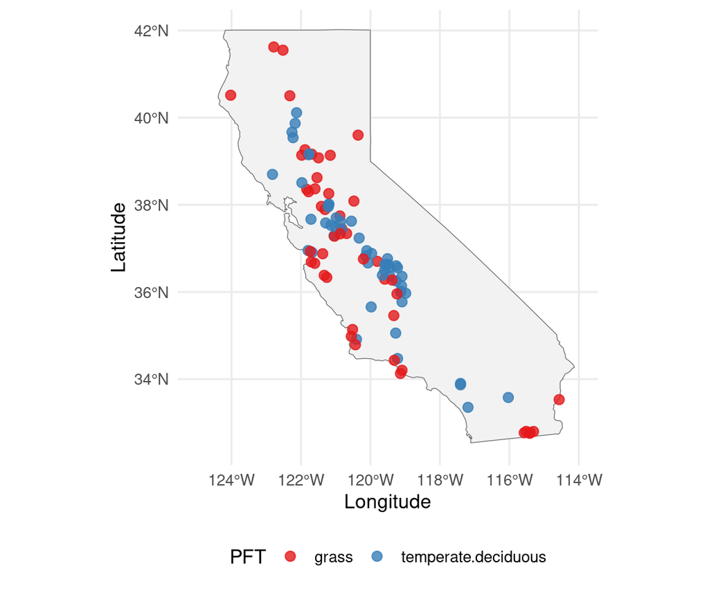

Figure 1: Design points across California croplands, colored by plant functional type. Grey boundary shows the state outline.

100 design points were selected via k-means clustering of environmental covariates (temperature, precipitation, solar radiation, vapor pressure deficit, soil clay content, organic carbon density, topographic wetness index) to capture the range of conditions across California croplands. 28 SIPNET parameters spanning photosynthesis, allocation, turnover, and phenology were analyzed for 3 response variables (Aboveground Biomass, Net Primary Productivity, Soil Carbon).

# 3 Results

## 3.1 Parameter rankings

Which parameters does SIPNET respond to most strongly? The figure below shows the top 15 parameters for each output variable, ranked by median absolute elasticity across sites. Points show median signed elasticity and whiskers show the interquartile range across sites. Absolute elasticity is used for ordering; the sign is preserved to indicate direction.

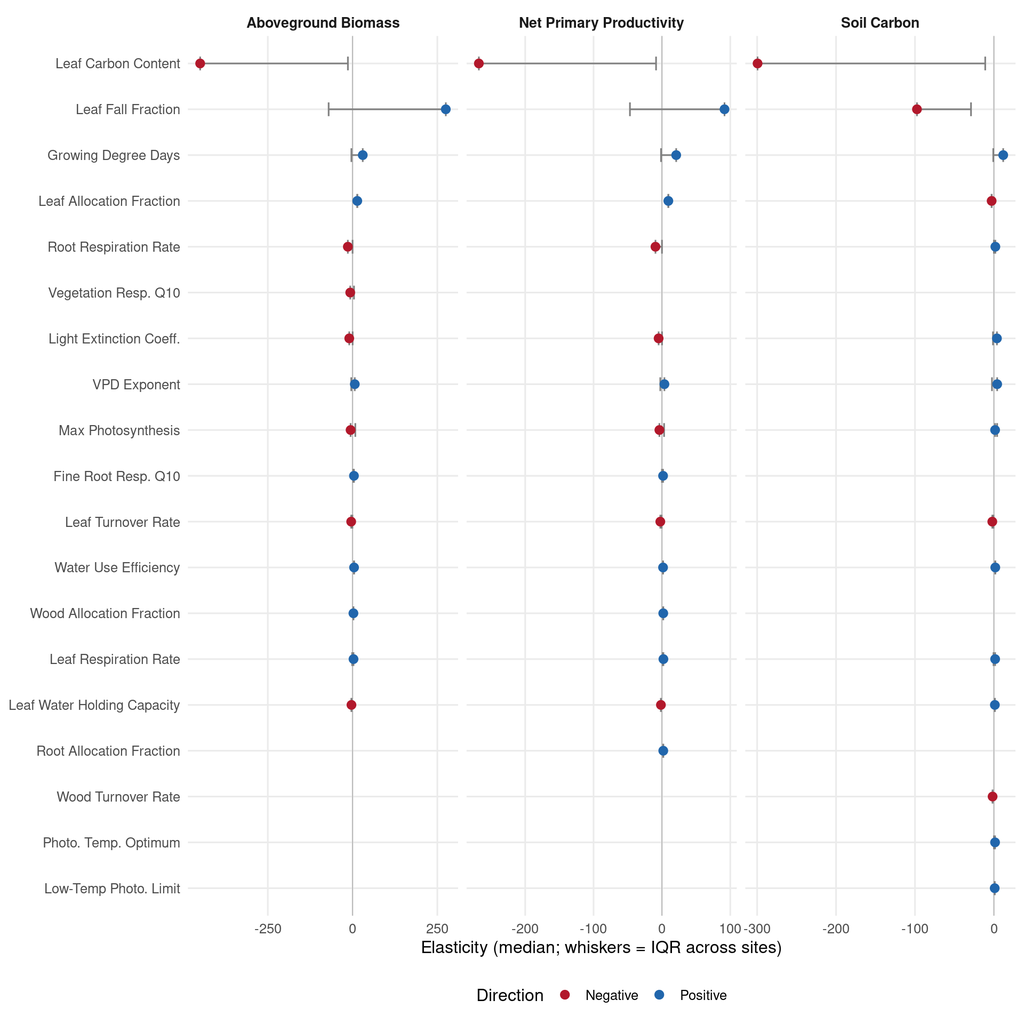

Figure 2: Top 15 parameters by median absolute elasticity per response variable. Points: median signed elasticity across sites. Whiskers: interquartile range. Positive (blue) means increasing the parameter increases the output.

Parameters with wide whiskers have site-dependent sensitivity and may require spatially explicit calibration. Parameters with narrow whiskers are consistently important (or unimportant) everywhere.

## 3.2 Cross-site variability

A key question is whether parameter importance changes with local conditions. The boxplots below show the full distribution of elasticity across all sites for the top 10 parameters, faceted by response variable.

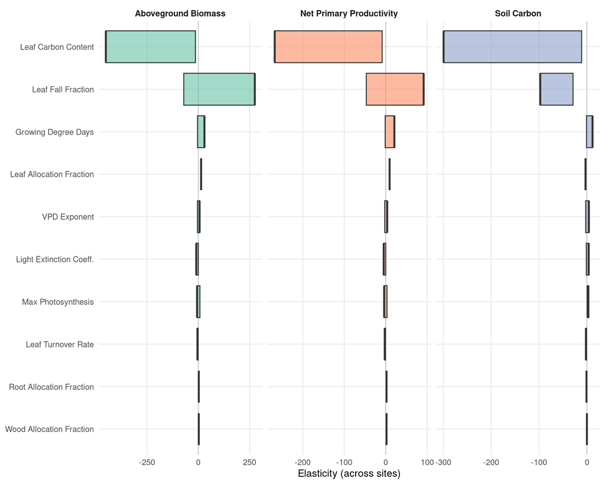

Figure 3: Distribution of signed elasticity across sites for the top 10 parameters. Each box shows the median, IQR, and outliers.

## 3.3 Overall sensitivity summary

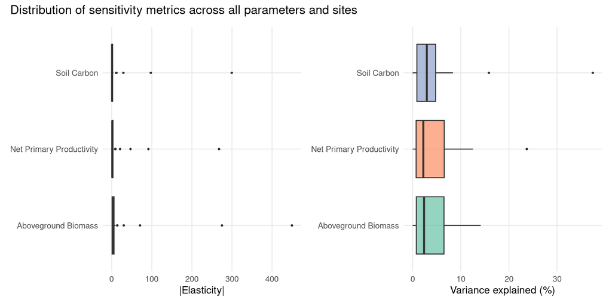

Figure 4: Summary of sensitivity metrics by response variable. Left: distribution of absolute elasticity. Right: distribution of variance explained (%).

## 3.4 Calibration priorities

Which parameters would benefit most from new measurements? The priority score $|\bar{\varepsilon}| \times \text{CV}$ identifies parameters that are both highly sensitive and poorly constrained by existing data, where field campaigns or trait synthesis would most efficiently reduce forecast uncertainty.

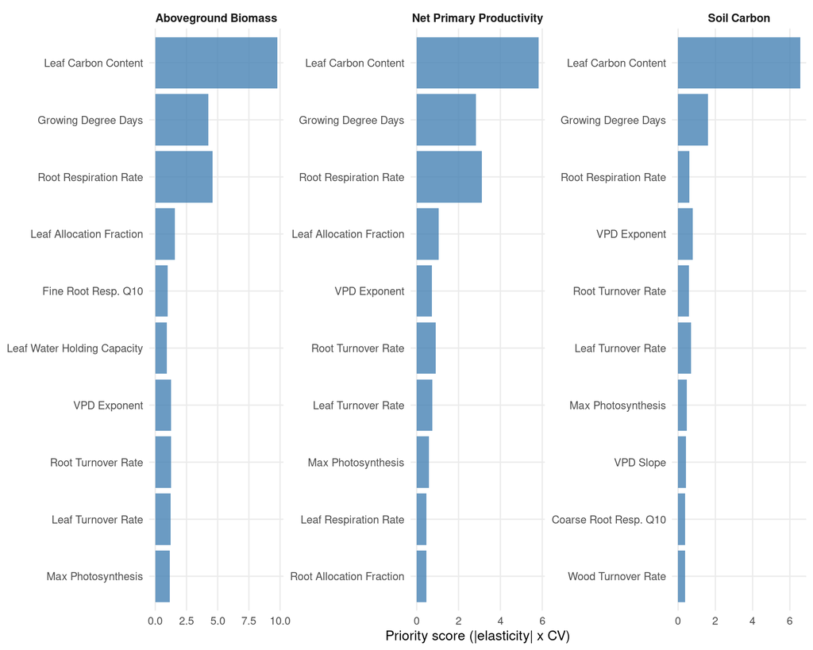

## 3.5 PFT comparisons

Parameter sensitivity may differ between woody perennial and annual herbaceous plant functional types, reflecting distinct physiological strategies. The figure below compares median signed elasticity for the top 10 parameters across PFTs, faceted by output variable.

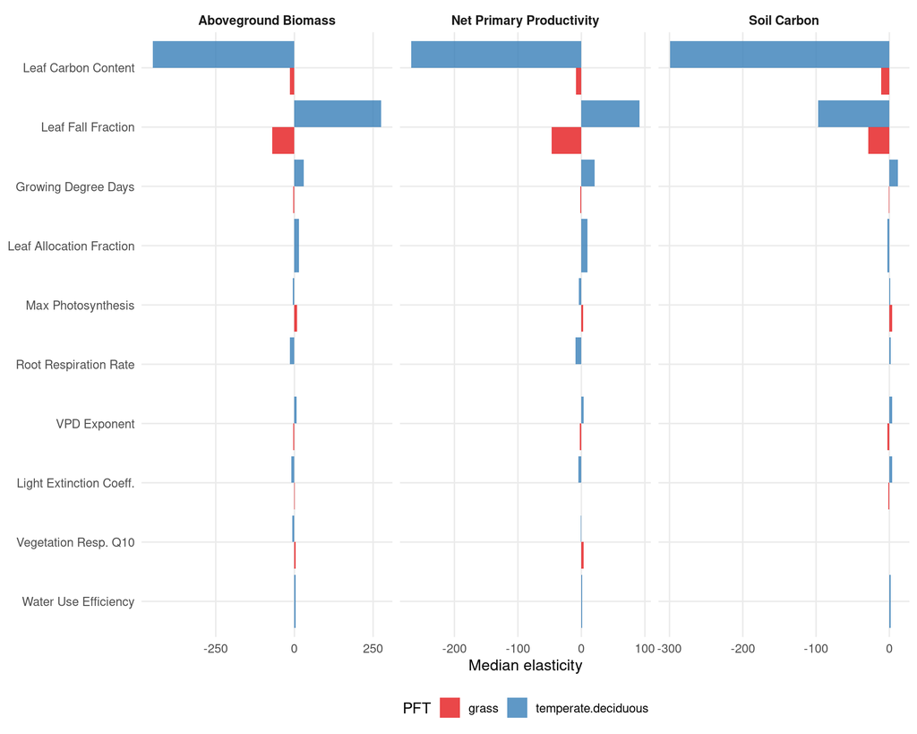

Figure 6: Top 10 parameters compared across PFTs. Bars show median signed elasticity within each PFT.

# 4 Environmental Gradient Analysis

Does parameter sensitivity vary systematically with climate or soil conditions? If so, calibration strategies should be tailored to local environments rather than applied uniformly.

For each parameter-response-gradient combination, we fit an OLS regression of signed elasticity against the environmental covariate and retain relationships with $R^2 > 0.10$. We report $R^2$ rather than p-values, since the number of tests is large and p-values from this many regressions require correction and are better suited for filtering than for inference.

```
No gradient relationships had matching site covariate data.
```

Note: these regressions assume a linear relationship. Non-linear relationships would be better captured with a global sensitivity approach (see the Global Sensitivity Analysis report).

# 5 Implications

# 6 Appendix: Technical Details

## 6.1 Sensitivity metrics

- **Elasticity** ($\varepsilon$): normalized sensitivity = $\frac{\partial Y}{\partial X} \cdot \frac{X}{Y}$. The sign indicates direction. Absolute elasticity is used for ranking importance.
- **Variance explained**: $\frac{\text{Partial Variance}_i}{\sum \text{Partial Variances}} \times 100\%$. Combines model sensitivity with prior parameter uncertainty.
- **Coefficient of variation** (CV): $\frac{\sigma}{\mu}$ of the posterior parameter distribution from the Bayesian meta-analysis. Quantifies remaining uncertainty after data constraint.
- **Calibration priority**: $|\bar{\varepsilon}| \times \text{CV}$. Parameters scoring highest have both high sensitivity and high uncertainty, making them the best targets for new data.

## 6.3 References

1. Dietze, M. C. et al. (2014). A quantitative assessment of a terrestrial biosphere model’s data needs across North American biomes. *J. Geophys. Res. Biogeosci.*, 119, 286-300.
2. LeBauer, D. S. et al. (2013). Facilitating feedbacks between field measurements and ecosystem models. *Ecological Monographs*, 83(2), 133-154.
3. Gelman, A. & Dodhia, R. (2002). Let’s practice what we preach: Turning tables into graphs.

## 6.5 Configuration

```
Config file: /projectnb/dietzelab/abv1/ccmmf/02_uncertainty/000-config.yml
```

```
Analysis date: 2026-04-08
```

```
Number of sites: 100
```

```
Number of parameters: 28
```

```
Response variables: Aboveground Biomass, Net Primary Productivity, Soil Carbon
```

```
Gradient variables: Mean Annual Temp., Mean Annual Precip., Clay Content, Organic C Density, Topographic Wetness
```

**Data Availability**

All datasets are available in `data/aggregated_sensitivity.csv` and related files. A downloadable CSV of the full parameter rankings is available in `data/parameter_rankings.csv`. Analysis code is in `R/local_sensitivity.R`.